# Lab3

Pedro Avila, Javier Benitez, Brandon Rivera

2026-03-13

```r
library(corrplot)
library(caret)
library(lmtest)
library(dplyr)
library(stringi)
library(cluster)
library(factoextra)
library(hopkins)
library(NbClust)
library(glmnet)
library(car)
library(rpart)
library(rpart.plot)
```

## 1. Descargue el conjunto de datos.

```r
load("Listings.RData")

head(listings, 5)
```

```
##      id                        listing_url    scrape_id last_scraped
## 1  5456  https://www.airbnb.com/rooms/5456 2.025092e+13   2025-09-17
## 2  6448  https://www.airbnb.com/rooms/6448 2.025092e+13   2025-09-17
## 3  8502  https://www.airbnb.com/rooms/8502 2.025092e+13   2025-09-17
## 4 13035 https://www.airbnb.com/rooms/13035 2.025092e+13   2025-09-17
## 5 22828 https://www.airbnb.com/rooms/22828 2.025092e+13   2025-09-16
##        source                                               name
## 1 city scrape          Walk to 6th, Rainey St and Convention Ctr
## 2 city scrape Secluded Studio @ Zilker - King Bed, Bright & Airy
## 3 city scrape                            Woodland Studio Lodging
## 4 city scrape      Historic house in highly walkable East Austin
## 5 city scrape                 Garage Apartment central SE Austin
##                                                                                                                                                                                                                                                                                                          …
## 1                                                                                                                                                                                                                                                                                                        …
## 2                                                                                                                           Clean, private space with everything you need for a quiet, comfy, private stay close to Zilker Park and Barton Springs, the river, parks, trails, and downtown. King bed, vau…
```

[output cut: 165 more lines]

## 2. Haga un análisis exploratorio extenso de los datos.

Explique bien todos los hallazgos. No ponga solo gráficas y código. Debe llegar a conclusiones interesantes para poder predecir. Explique el preprocesamiento que necesitó hacer

### 2.1. Descripción de las variables

```r
summary(listings)
```

```
##        id            listing_url          scrape_id         last_scraped
##  Min.   :6.000e+00   Length:171748      Min.   :2.025e+13   Length:171748
##  1st Qu.:3.599e+07   Class :character   1st Qu.:2.025e+13   Class :character
##  Median :7.250e+17   Mode  :character   Median :2.025e+13   Mode  :character
##  Mean   :6.363e+17                      Mean   :2.025e+13
##  3rd Qu.:1.183e+18                      3rd Qu.:2.025e+13
##  Max.   :1.568e+18                      Max.   :2.025e+13
##
##     source              name           description        neighborhood_overview
##  Length:171748      Length:171748      Length:171748      Length:171748
##  Class :character   Class :character   Class :character   Class :character
##  Mode  :character   Mode  :character   Mode  :character   Mode  :character
##
##
##
##
##  picture_url           host_id            host_url          host_name
##  Length:171748      Min.   :       23   Length:171748      Length:171748
##  Class :character   1st Qu.: 26330631   Class :character   Class :character
##  Mode  :character   Median :108058504   Mode  :character   Mode  :character
##                     Mean   :200257103
##                     3rd Qu.:376574507
##                     Max.   :732092326
##
##   host_since        host_location       host_about        host_response_time
##  Length:171748      Length:171748      Length:171748      Length:171748
##  Class :character   Class :character   Class :character   Class :character
##  Mode  :character   Mode  :character   Mode  :character   Mode  :character
##
##
##
##
##  host_response_rate host_acceptance_rate host_is_superhost  host_thumbnail_url
##  Length:171748      Length:171748        Length:171748      Length:171748
##  Class :character   Class :character     Class :character   Class :character
##  Mode  :character   Mode  :character     Mode  :character   Mode  :character
##
##
##
##
```

[output cut: 153 more lines]

```
##  Min.   : 0.00000                            Min.   :  0.010
##  1st Qu.: 0.00000                            1st Qu.:  0.190
##  Median : 0.00000                            Median :  0.700
##  Mean   : 0.08211                            Mean   :  1.344
##  3rd Qu.: 0.00000                            3rd Qu.:  2.000
##  Max.   :60.00000                            Max.   :120.370
##                                              NA's   :40287
##      city
##  Length:171748
##  Class :character
##  Mode  :character
##
##
##
##
```

```r
cual_nominales <- c(
    "listing_url",
    "source",
    "name",
    "description",
    "neighborhood_overview",
    "picture_url",
    "host_url",
    "host_name",
    "host_location",
    "host_about",
    "host_is_superhost",
    "host_thumbnail_url",
    "host_picture_url",
    "host_neighbourhood",
    "host_verifications",
    "host_has_profile_pic",
    "host_identity_verified",
    "neighbourhood",
    "neighbourhood_cleansed",
    "neighbourhood_group_cleansed",
    "bathrooms_text",
    "amenities",
    "has_availability",
    "license",
    "instant_bookable",
    "city"
)

cual_ordinales <- c(
    "last_scraped",
    "host_response_time",
    "host_since",
    "property_type",
    "room_type",
    "calendar_last_scraped",
    "first_review",
    "last_review"
)


cuant_discretas <- c(
    "host_listings_count",
    "host_total_listings_count",
    "accommodates",
    "bedrooms",
    "beds",
    "minimum_nights",
    "minimum_nights_avg_ntm",
    "maximum_nights",
    "maximum_nights_avg_ntm",
    "minimum_minimum_nights",
    "maximum_minimum_nights",
    "availability_30",
    "availability_60",
    "availability_90",
    "availability_365",
    "number_of_reviews",
    "number_of_reviews_ltm",
    "number_of_reviews_l30d",
    "availability_eoy",
    "number_of_reviews_ly",
    "estimated_occupancy_l365d",
    "reviews_per_month",
    "minimum_maximum_nights",
    "maximum_maximum_nights"
)

cuant_continuas <- c(
    "host_response_rate",
    "host_acceptance_rate",
    "latitude",
    "longitude",
    "bathrooms",
    "price",
    "review_scores_rating",
    "review_scores_accuracy",
    "review_scores_cleanliness",
    "review_scores_checkin",
    "review_scores_communication",
    "review_scores_location",
    "review_scores_value",
    "calculated_host_listings_count",
    "calculated_host_listings_count_entire_homes",
    "calculated_host_listings_count_private_rooms",
    "calculated_host_listings_count_shared_rooms",
    "estimated_revenue_l365d"
)

cuantitativas <- c(cuant_discretas, cuant_continuas)
cuantitativas
```

```
##  [1] "host_listings_count"
##  [2] "host_total_listings_count"
##  [3] "accommodates"
##  [4] "bedrooms"
##  [5] "beds"
##  [6] "minimum_nights"
##  [7] "minimum_nights_avg_ntm"
##  [8] "maximum_nights"
##  [9] "maximum_nights_avg_ntm"
## [10] "minimum_minimum_nights"
## [11] "maximum_minimum_nights"
## [12] "availability_30"
## [13] "availability_60"
## [14] "availability_90"
## [15] "availability_365"
```

[output cut: 27 more lines]

```r
datos_cuant <- listings[, cuantitativas]
head(datos_cuant, 5)
```

```
##   host_listings_count host_total_listings_count accommodates bedrooms beds
## 1                   1                         2            3        1    2
## 2                   1                         2            2        1    2
## 3                   1                         1            2        1    1
## 4                   2                         2            3        2    2
## 5                   1                         1            2        1    1
##   minimum_nights minimum_nights_avg_ntm maximum_nights maximum_nights_avg_ntm
## 1              2                    2.1             90                     90
## 2              3                    3.0            365                   1125
## 3              4                    6.0             90                     90
## 4             15                   15.0            150                    150
## 5             30                   30.0            365                    365
##   minimum_minimum_nights maximum_minimum_nights availability_30 availability_60
## 1                      2                      4              13              35
## 2                      3                      3              12              30
```

[output cut: 63 more lines]

```r
cualitativas <- c(cual_nominales, cual_ordinales)
cualitativas
```

```
##  [1] "listing_url"                  "source"
##  [3] "name"                         "description"
##  [5] "neighborhood_overview"        "picture_url"
##  [7] "host_url"                     "host_name"
##  [9] "host_location"                "host_about"
## [11] "host_is_superhost"            "host_thumbnail_url"
## [13] "host_picture_url"             "host_neighbourhood"
## [15] "host_verifications"           "host_has_profile_pic"
## [17] "host_identity_verified"       "neighbourhood"
## [19] "neighbourhood_cleansed"       "neighbourhood_group_cleansed"
## [21] "bathrooms_text"               "amenities"
## [23] "has_availability"             "license"
## [25] "instant_bookable"             "city"
## [27] "last_scraped"                 "host_response_time"
## [29] "host_since"                   "property_type"
## [31] "room_type"                    "calendar_last_scraped"
## [33] "first_review"                 "last_review"
```

```r
datos_cual <- listings[, cualitativas]
head(datos_cual, 5)
```

```
##                          listing_url      source
## 1  https://www.airbnb.com/rooms/5456 city scrape
## 2  https://www.airbnb.com/rooms/6448 city scrape
## 3  https://www.airbnb.com/rooms/8502 city scrape
## 4 https://www.airbnb.com/rooms/13035 city scrape
## 5 https://www.airbnb.com/rooms/22828 city scrape
##                                                 name
## 1          Walk to 6th, Rainey St and Convention Ctr
## 2 Secluded Studio @ Zilker - King Bed, Bright & Airy
## 3                            Woodland Studio Lodging
## 4      Historic house in highly walkable East Austin
## 5                 Garage Apartment central SE Austin
##                                                                                                                                                                                                                                                                                                          …
## 1                                                                                                                                                                                                                                                                                                        …
## 2                                                                                                                           Clean, private space with everything you need for a quiet, comfy, private stay close to Zilker Park and Barton Springs, the river, parks, trails, and downtown. King bed, vau…
```

[output cut: 87 more lines]

Variables cuantitativas discretas no decidimos clasificarlas id , scrape_id , host_id. Adicionalmente la variable calendar_updated se decidio no incluirla ya que toda su data es NA

### 2.2. Análisis exploratorio

```r
library(ggplot2)

dim(listings)
```

```
## [1] 171748     80
```

```r
str(listings)
```

```
## 'data.frame':    171748 obs. of  80 variables:
##  $ id                                          : num  5456 6448 8502 13035 22828 ...
##  $ listing_url                                 : chr  "https://www.airbnb.com/rooms/5456" "https://www.airbnb.com/rooms/6448" "https://www.airbnb.com/rooms/8502" "https://www.airbnb.com/rooms/13035" ...
##  $ scrape_id                                   : num  2.03e+13 2.03e+13 2.03e+13 2.03e+13 2.03e+13 ...
##  $ last_scraped                                : chr  "2025-09-17" "2025-09-17" "2025-09-17" "2025-09-17" ...
##  $ source                                      : chr  "city scrape" "city scrape" "city scrape" "city scrape" ...
##  $ name                                        : chr  "Walk to 6th, Rainey St and Convention Ctr" "Secluded Studio @ Zilker - King Bed, Bright & Airy" "Woodland Studio Lodging" "Historic house in highly walkable East Austin" ...
##  $ description                                 : chr  "Great central  location for walking to Convention Center, Rainey Street, East 6th Street, Downtown, Congress Av"| __truncated__ "Clean, private space with everything you need for a quiet, comfy, private stay close to Zilker Park and Barton "|…
##  $ neighborhood_overview                       : chr  "My neighborhood is ideally located if you want to walk to bars and restaurants downtown, East 6th Street or Rai"| __truncated__ "The neighborhood is fun and funky (but quiet)! People are friendly  and you can't beat the location." "" "East Ce…
##  $ picture_url                                 : chr  "https://a0.muscache.com/pictures/14084884/b5a35a84_original.jpg" "https://a0.muscache.com/pictures/airflow/Hosting-6448/original/a0ab6e9c-58ed-4d57-acb1-60cb68b068e0.jpg" "https://a0.muscache.com/pictures/miso/Hosting-8502/original/be48ea3b-6…
##  $ host_id                                     : int  8028 14156 25298 50793 56488 215917 230747 272156 268988 378744 ...
##  $ host_url                                    : chr  "https://www.airbnb.com/users/show/8028" "https://www.airbnb.com/users/show/14156" "https://www.airbnb.com/users/show/25298" "https://www.airbnb.com/users/show/50793" ...
##  $ host_name                                   : chr  "Sylvia" "Amy" "Karen" "Margaret Ann" ...
##  $ host_since                                  : chr  "2009-02-16" "2009-04-20" "2009-07-11" "2009-11-02" ...
##  $ host_location                               : chr  "Austin, TX" "Austin, TX" "Austin, TX" "Austin, TX" ...
```

[output cut: 66 more lines]

```r
summary(listings)
```

```
##        id            listing_url          scrape_id         last_scraped
##  Min.   :6.000e+00   Length:171748      Min.   :2.025e+13   Length:171748
##  1st Qu.:3.599e+07   Class :character   1st Qu.:2.025e+13   Class :character
##  Median :7.250e+17   Mode  :character   Median :2.025e+13   Mode  :character
##  Mean   :6.363e+17                      Mean   :2.025e+13
##  3rd Qu.:1.183e+18                      3rd Qu.:2.025e+13
##  Max.   :1.568e+18                      Max.   :2.025e+13
##
##     source              name           description        neighborhood_overview
##  Length:171748      Length:171748      Length:171748      Length:171748
##  Class :character   Class :character   Class :character   Class :character
##  Mode  :character   Mode  :character   Mode  :character   Mode  :character
##
##
##
##
##  picture_url           host_id            host_url          host_name
##  Length:171748      Min.   :       23   Length:171748      Length:171748
##  Class :character   1st Qu.: 26330631   Class :character   Class :character
##  Mode  :character   Median :108058504   Mode  :character   Mode  :character
##                     Mean   :200257103
##                     3rd Qu.:376574507
##                     Max.   :732092326
##
##   host_since        host_location       host_about        host_response_time
##  Length:171748      Length:171748      Length:171748      Length:171748
##  Class :character   Class :character   Class :character   Class :character
##  Mode  :character   Mode  :character   Mode  :character   Mode  :character
##
##
##
##
##  host_response_rate host_acceptance_rate host_is_superhost  host_thumbnail_url
##  Length:171748      Length:171748        Length:171748      Length:171748
##  Class :character   Class :character     Class :character   Class :character
##  Mode  :character   Mode  :character     Mode  :character   Mode  :character
##
##
##
##
```

[output cut: 153 more lines]

```
##  Min.   : 0.00000                            Min.   :  0.010
##  1st Qu.: 0.00000                            1st Qu.:  0.190
##  Median : 0.00000                            Median :  0.700
##  Mean   : 0.08211                            Mean   :  1.344
##  3rd Qu.: 0.00000                            3rd Qu.:  2.000
##  Max.   :60.00000                            Max.   :120.370
##                                              NA's   :40287
##      city
##  Length:171748
##  Class :character
##  Mode  :character
##
##
##
##
```

```r
colSums(is.na(listings))
```

```
##                                           id
##                                            0
##                                  listing_url
##                                            0
##                                    scrape_id
##                                            0
##                                 last_scraped
##                                            0
##                                       source
##                                            0
##                                         name
##                                            0
##                                  description
##                                            0
##                        neighborhood_overview
##                                            0
##                                  picture_url
##                                            0
##                                      host_id
##                                            0
##                                     host_url
##                                            0
##                                    host_name
##                                            0
##                                   host_since
##                                            0
##                                host_location
##                                            0
##                                   host_about
##                                            1
##                           host_response_time
##                                            0
##                           host_response_rate
##                                            0
##                         host_acceptance_rate
##                                            0
##                            host_is_superhost
##                                            0
##                           host_thumbnail_url
##                                            0
```

[output cut: 105 more lines]

```
##                                        10533
##                             instant_bookable
##                                            0
##               calculated_host_listings_count
##                                            0
##  calculated_host_listings_count_entire_homes
##                                            0
## calculated_host_listings_count_private_rooms
##                                            0
##  calculated_host_listings_count_shared_rooms
##                                            0
##                            reviews_per_month
##                                        40287
##                                         city
##                                            0
```

```r
datos_cuant <- listings[, cuantitativas]
datos_cual  <- listings[, cualitativas]


listings$price <- as.numeric(gsub("[$,]", "", listings$price))
listings$host_response_rate <- as.numeric(gsub("%", "", listings$host_response_rate))
listings$host_acceptance_rate <- as.numeric(gsub("%", "", listings$host_acceptance_rate))

summary(datos_cuant)
```

```
##  host_listings_count host_total_listings_count  accommodates
##  Min.   :   0.0      Min.   :    0.0           Min.   : 1.000
##  1st Qu.:   1.0      1st Qu.:    2.0           1st Qu.: 2.000
##  Median :   4.0      Median :    6.0           Median : 4.000
##  Mean   : 190.7      Mean   :  274.6           Mean   : 4.107
##  3rd Qu.:  30.0      3rd Qu.:   43.0           3rd Qu.: 6.000
##  Max.   :5531.0      Max.   :10050.0           Max.   :16.000
##  NA's   :876         NA's   :876
##     bedrooms           beds         minimum_nights minimum_nights_avg_ntm
##  Min.   : 0.000   Min.   :  0.000   Min.   :   1   Min.   :   0.70
##  1st Qu.: 1.000   1st Qu.:  1.000   1st Qu.:   2   1st Qu.:   2.00
##  Median : 1.000   Median :  2.000   Median :   4   Median :   4.40
##  Mean   : 1.718   Mean   :  2.345   Mean   :  17   Mean   :  17.49
##  3rd Qu.: 2.000   3rd Qu.:  3.000   3rd Qu.:  30   3rd Qu.:  30.00
##  Max.   :57.000   Max.   :132.000   Max.   :1125   Max.   :1125.00
##  NA's   :10473    NA's   :31686
##  maximum_nights      maximum_nights_avg_ntm minimum_minimum_nights
##  Min.   :1.000e+00   Min.   :1.000e+00      Min.   :   0.00
##  1st Qu.:9.000e+01   1st Qu.:2.290e+02      1st Qu.:   2.00
##  Median :3.650e+02   Median :3.650e+02      Median :   3.00
##  Mean   :1.299e+04   Mean   :1.475e+06      Mean   :  16.54
##  3rd Qu.:1.125e+03   3rd Qu.:1.125e+03      3rd Qu.:  30.00
##  Max.   :2.147e+09   Max.   :2.147e+09      Max.   :1125.00
##                                             NA's   :71
##  maximum_minimum_nights availability_30 availability_60 availability_90
##  Min.   :   1.00        Min.   : 0.00   Min.   : 0.00   Min.   : 0.00
##  1st Qu.:   2.00        1st Qu.: 0.00   1st Qu.: 5.00   1st Qu.:15.00
##  Median :   7.00        Median :12.00   Median :33.00   Median :59.00
##  Mean   :  23.53        Mean   :13.37   Mean   :30.96   Mean   :50.07
##  3rd Qu.:  30.00        3rd Qu.:25.00   3rd Qu.:53.00   3rd Qu.:82.00
##  Max.   :1125.00        Max.   :30.00   Max.   :60.00   Max.   :90.00
##  NA's   :71
##  availability_365 number_of_reviews number_of_reviews_ltm
##  Min.   :  0.0    Min.   :   0      Min.   :   0.000
##  1st Qu.: 86.0    1st Qu.:   1      1st Qu.:   0.000
##  Median :242.0    Median :   8      Median :   1.000
##  Mean   :207.4    Mean   :  44      Mean   :   8.783
##  3rd Qu.:333.0    3rd Qu.:  46      3rd Qu.:  10.000
##  Max.   :365.0    Max.   :3920      Max.   :1565.000
##
```

[output cut: 57 more lines]

```
##  Min.   :  0.000
##  1st Qu.:  0.000
##  Median :  0.000
##  Mean   :  5.539
##  3rd Qu.:  1.000
##  Max.   :567.000
##
##  calculated_host_listings_count_shared_rooms estimated_revenue_l365d
##  Min.   : 0.00000                            Min.   :       0
##  1st Qu.: 0.00000                            1st Qu.:       0
##  Median : 0.00000                            Median :    7650
##  Mean   : 0.08211                            Mean   :   18284
##  3rd Qu.: 0.00000                            3rd Qu.:   23224
##  Max.   :60.00000                            Max.   :12750000
##                                              NA's   :95502
```

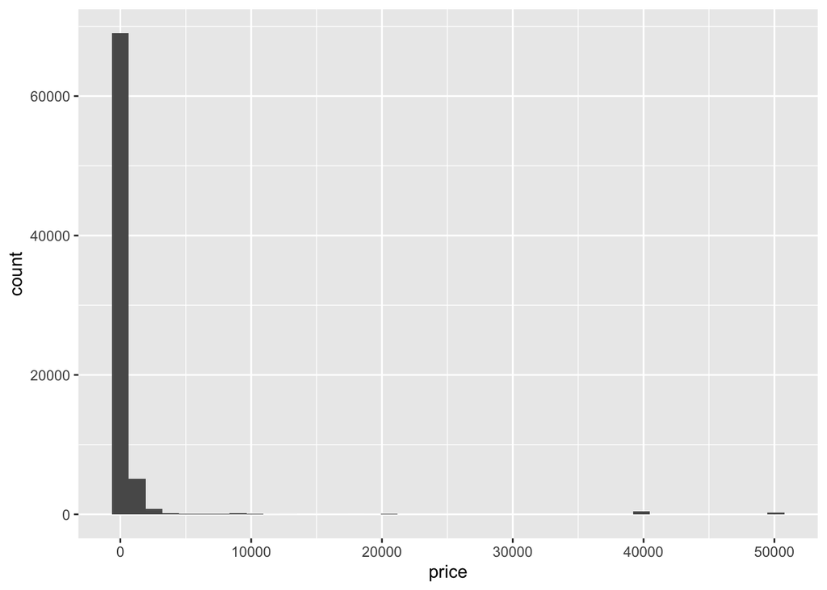

```r
ggplot(listings, aes(x = price)) +
  geom_histogram(bins = 40)
```

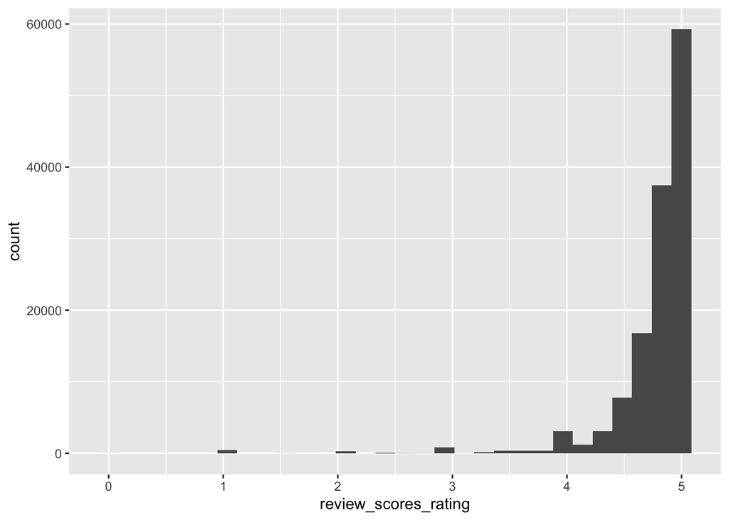

```r
ggplot(listings, aes(x = review_scores_rating)) +
  geom_histogram(bins = 30)
```

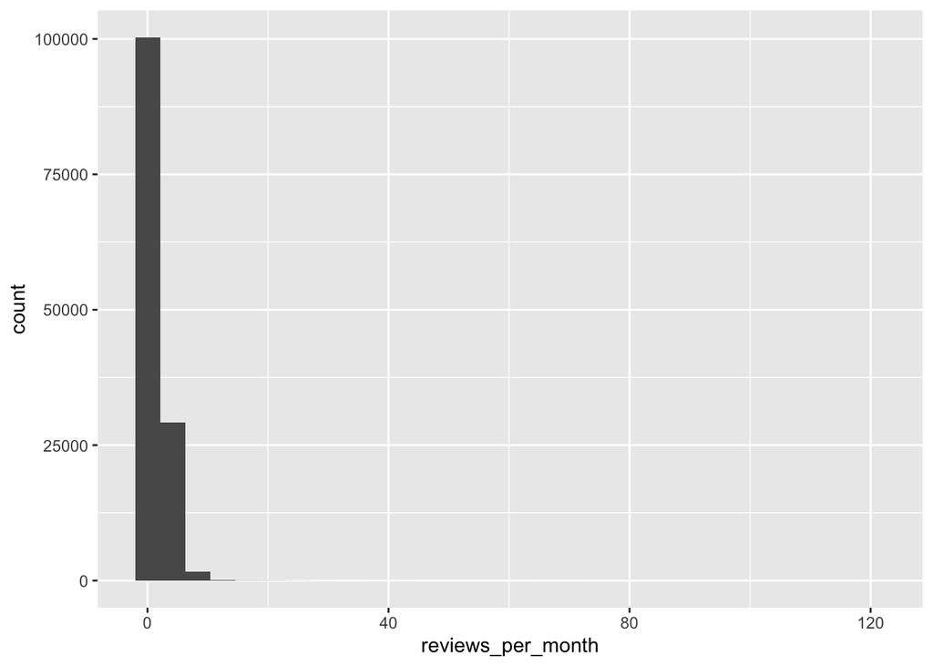

```r
ggplot(listings, aes(x = reviews_per_month)) +
  geom_histogram(bins = 30)
```

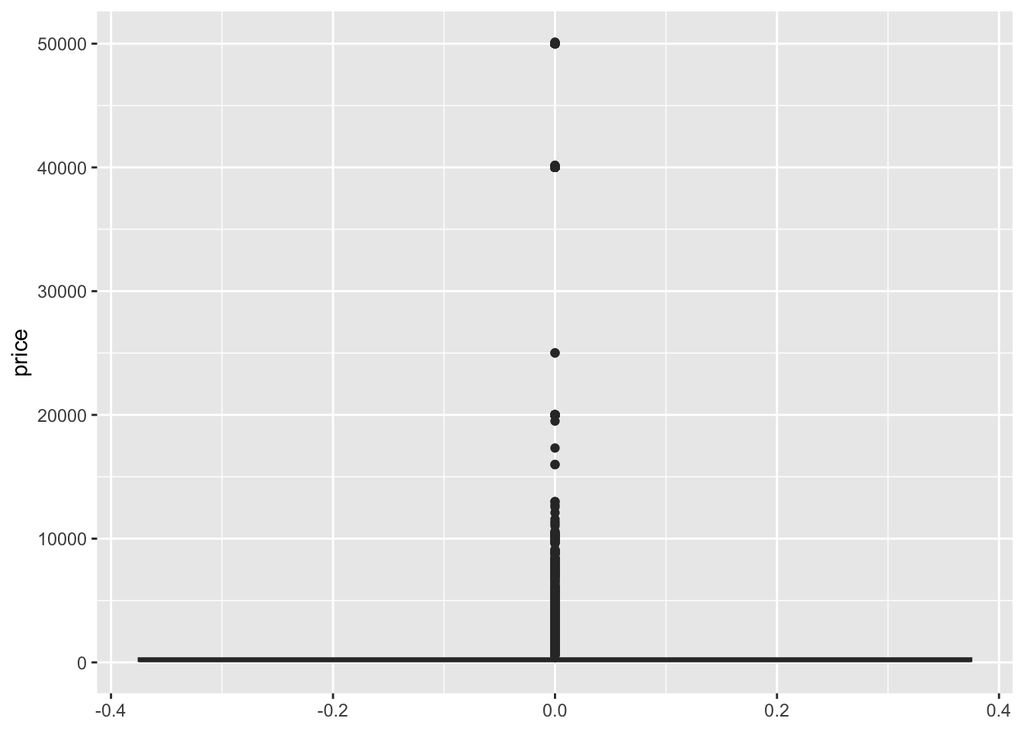

```r
ggplot(listings, aes(y = price)) +
  geom_boxplot()
```

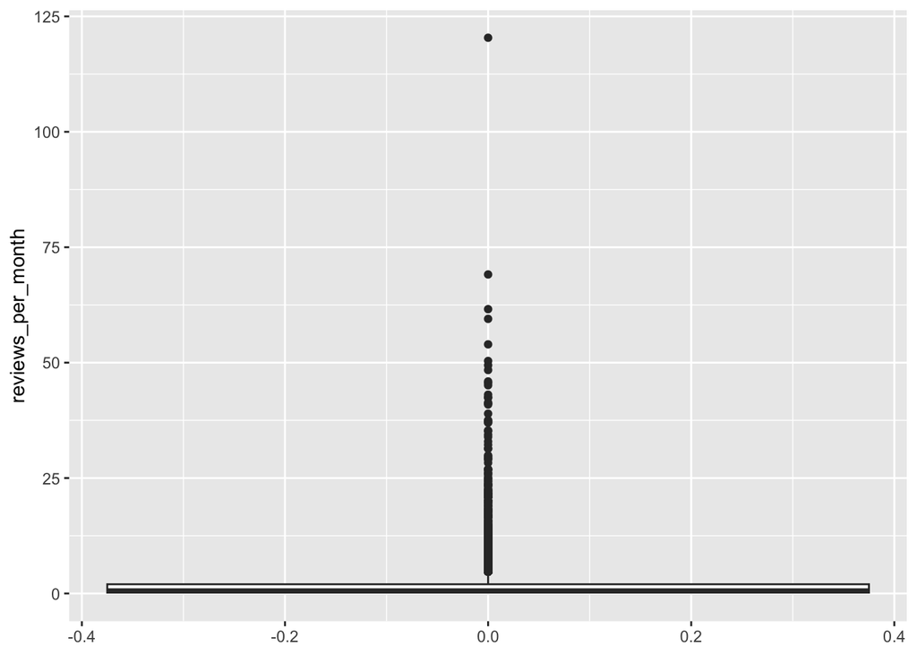

```r
ggplot(listings, aes(y = reviews_per_month)) +
  geom_boxplot()
```

Podemos ver que los datos los cuales principalmente podriamos hacer analisis numerico llegan a tener sesgos cada uno por su lado

```r
shapiro.test(sample(na.omit(listings$price), 5000))
```

```
##
##  Shapiro-Wilk normality test
##
## data:  sample(na.omit(listings$price), 5000)
## W = 0.12565, p-value < 2.2e-16
```

```r
shapiro.test(sample(na.omit(listings$review_scores_rating), 5000))
```

```
##
##  Shapiro-Wilk normality test
##
## data:  sample(na.omit(listings$review_scores_rating), 5000)
## W = 0.53405, p-value < 2.2e-16
```

```r
shapiro.test(sample(na.omit(listings$reviews_per_month), 5000))
```

```
##
##  Shapiro-Wilk normality test
##
## data:  sample(na.omit(listings$reviews_per_month), 5000)
## W = 0.75081, p-value < 2.2e-16
```

Haciendo la prueba de shapiro-wilks podemos darnos cuenta por que el p-value llega a estar mas abajo que el alpha autoimpuesto de 0.5, podemos darnos cuenta que no es normal.

### 2.3. Análisis de relaciones con la variable respuesta

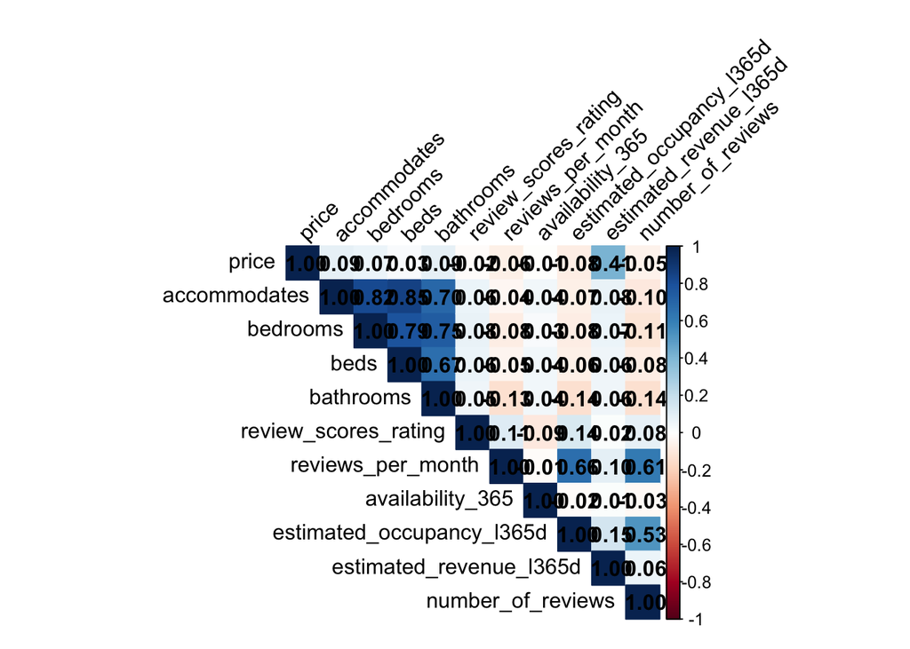

```r
library(corrplot)

vars_interes <- c("price", "accommodates", "bedrooms", "beds", "bathrooms",
                  "review_scores_rating", "reviews_per_month",
                  "availability_365", "estimated_occupancy_l365d",
                  "estimated_revenue_l365d", "number_of_reviews")

cor_data <- listings[, vars_interes]
cor_data <- cor_data[complete.cases(cor_data), ]

cor_matrix <- cor(cor_data)

corrplot(cor_matrix, method = "color", type = "upper",
         addCoef.col = "black", tl.col = "black", tl.srt = 45,
         mar = c(0,0,1,0))
```

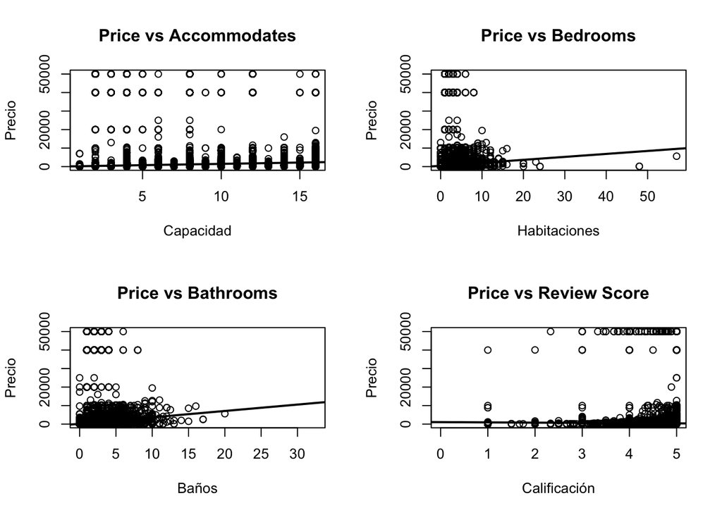

```r
par(mfrow = c(2, 2))

plot(listings$accommodates, listings$price,
     main = "Price vs Accommodates",
     xlab = "Capacidad", ylab = "Precio")
abline(lm(price ~ accommodates, data = listings), col = "black", lwd = 2)

plot(listings$bedrooms, listings$price,
     main = "Price vs Bedrooms",
     xlab = "Habitaciones", ylab = "Precio")
abline(lm(price ~ bedrooms, data = listings), col = "black", lwd = 2)

plot(listings$bathrooms, listings$price,
     main = "Price vs Bathrooms",
     xlab = "Baños", ylab = "Precio")
abline(lm(price ~ bathrooms, data = listings), col = "black", lwd = 2)

plot(listings$review_scores_rating, listings$price,
     main = "Price vs Review Score",
     xlab = "Calificación", ylab = "Precio")
abline(lm(price ~ review_scores_rating, data = listings), col = "black", lwd = 2)
```

```r
par(mfrow = c(1, 1))
```

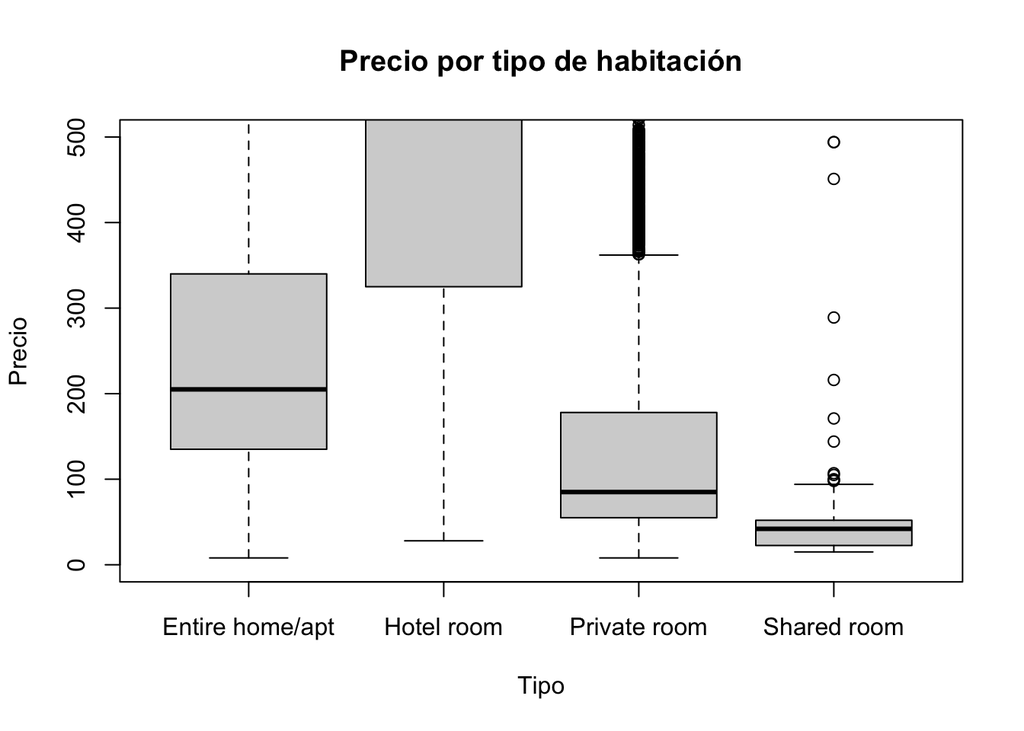

```r
boxplot(price ~ room_type, data = listings,
        main = "Precio por tipo de habitación",
        xlab = "Tipo", ylab = "Precio",
        ylim = c(0, 500))
```

```r
kruskal.test(price ~ room_type, data = listings)
```

```
##
##  Kruskal-Wallis rank sum test
##
## data:  price by room_type
## Kruskal-Wallis chi-squared = 8225.6, df = 3, p-value < 2.2e-16
```

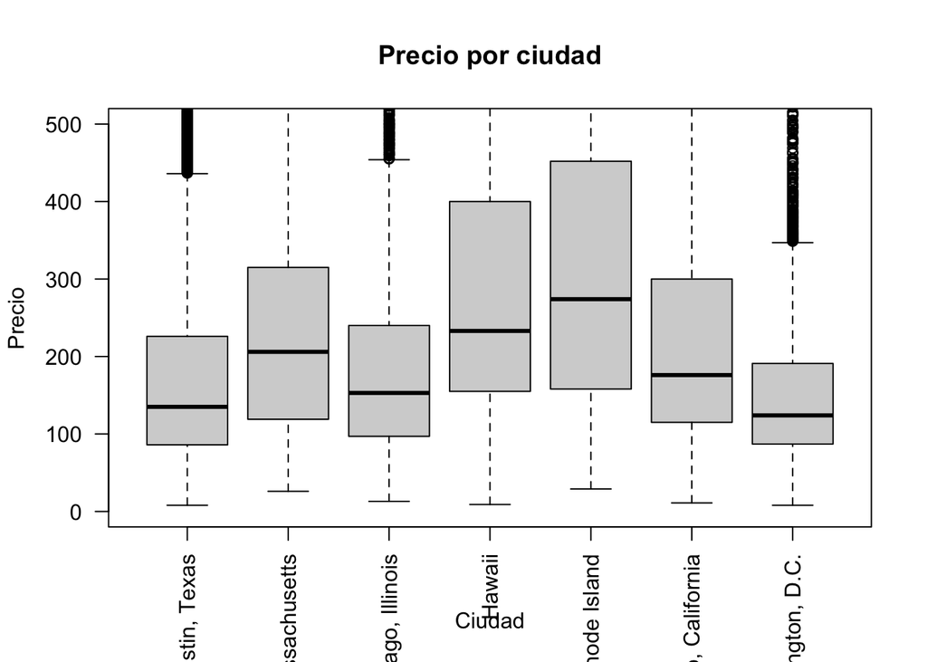

```r
boxplot(price ~ city, data = listings,
        main = "Precio por ciudad",
        xlab = "Ciudad", ylab = "Precio",
        ylim = c(0, 500),
        las = 2)
```

```r
kruskal.test(price ~ city, data = listings)
```

```
##
##  Kruskal-Wallis rank sum test
##
## data:  price by city
## Kruskal-Wallis chi-squared = 8184.1, df = 6, p-value < 2.2e-16
```

El precio varía según la ciudad, siendo la ubicación un factor relevante (p < 0.05).

## 3. Incluya un análisis de grupos en el análisis exploratorio.

Explique las características de cada uno.

Clustering

```r
set.seed(123)

vars_cluster <- c("price", "accommodates", "bedrooms", "beds",
                  "bathrooms", "review_scores_rating",
                  "availability_365", "estimated_occupancy_l365d")

datos_cluster <- listings[, vars_cluster]
datos_cluster <- datos_cluster[complete.cases(datos_cluster), ]

# Tomar muestra representativa (máximo 3000-5000 filas)
n_muestra <- min(3000, nrow(datos_cluster))
idx_muestra <- sample(1:nrow(datos_cluster), n_muestra)
datos_muestra <- datos_cluster[idx_muestra, ]

# Escalar
datos_scaled <- scale(datos_muestra[, vars_cluster])

### Hopkins
set.seed(123)

idx_hopkins <- sample(1:nrow(datos_scaled), 500)
hopkins(datos_scaled[idx_hopkins, ])
```

```
## [1] 0.9999552
```

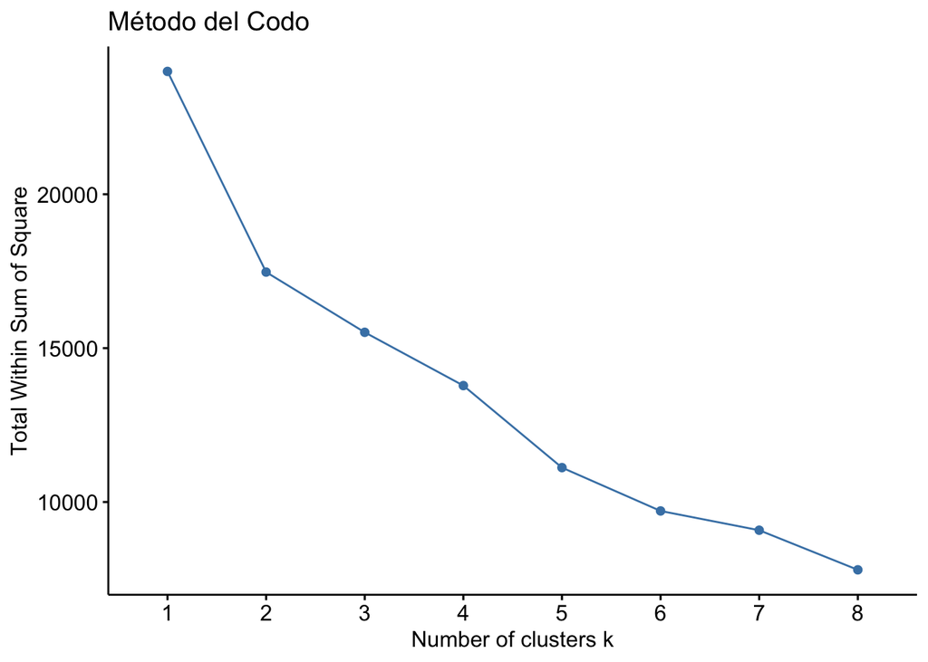

```r
# Codo - rápido
fviz_nbclust(datos_scaled, kmeans,
             method = "wss",
             k.max = 8) +
  labs(title = "Método del Codo")
```

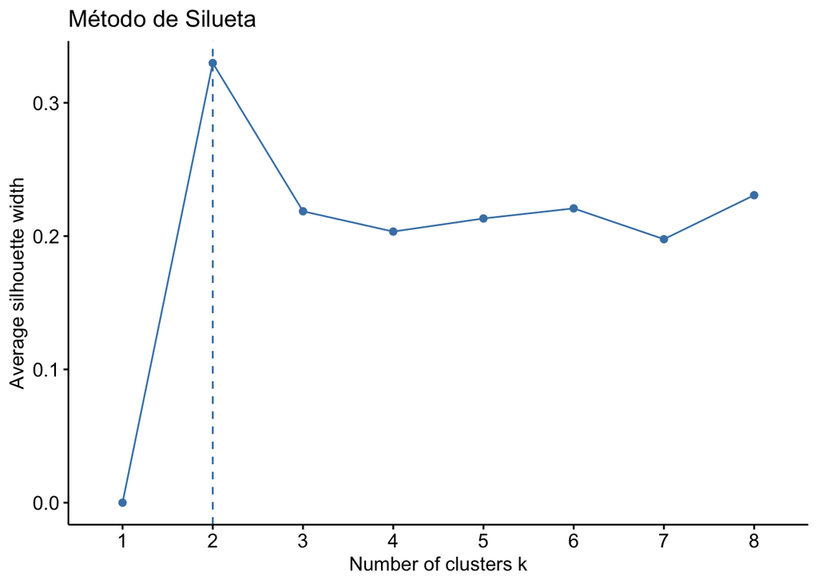

```r
# Silueta - rápido
fviz_nbclust(datos_scaled, kmeans,
             method = "silhouette",
             k.max = 8) +
  labs(title = "Método de Silueta")
```

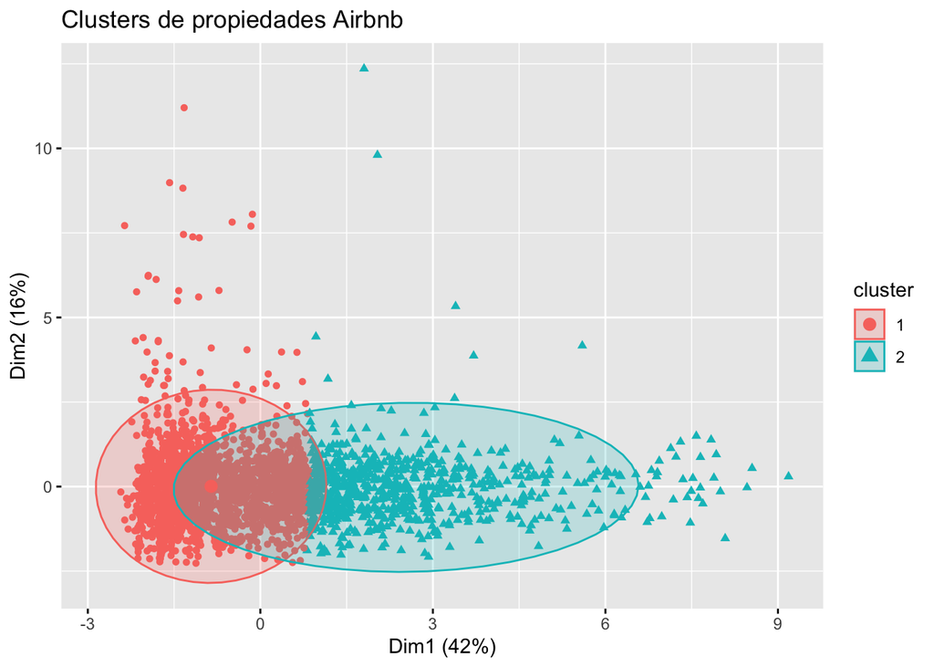

```r
set.seed(123)
k_optimo <- 2

km <- kmeans(datos_scaled,
             centers = k_optimo,
             iter.max = 100,
             nstart = 10)   # reducir nstart también ayuda

datos_muestra$grupo <- as.factor(km$cluster)

fviz_cluster(km, data = datos_scaled,
             geom = "point",
             ellipse.type = "norm") +
  labs(title = "Clusters de propiedades Airbnb")
```

```r
library(dplyr)

perfil <- datos_muestra %>%
  group_by(grupo) %>%
  summarise(across(all_of(vars_cluster), mean, na.rm = TRUE)) %>%
  mutate(across(where(is.numeric), ~round(., 2)))
print(perfil)
```

```
## # A tibble: 2 × 9
##   grupo price accommodates bedrooms  beds bathrooms review_scores_rating
##   <fct> <dbl>        <dbl>    <dbl> <dbl>     <dbl>                <dbl>
## 1 1      439.         3.54     1.23  1.86      1.23                 4.79
## 2 2      702.         8.61     3.49  4.95      2.64                 4.84
## # ℹ 2 more variables: availability_365 <dbl>, estimated_occupancy_l365d <dbl>
```

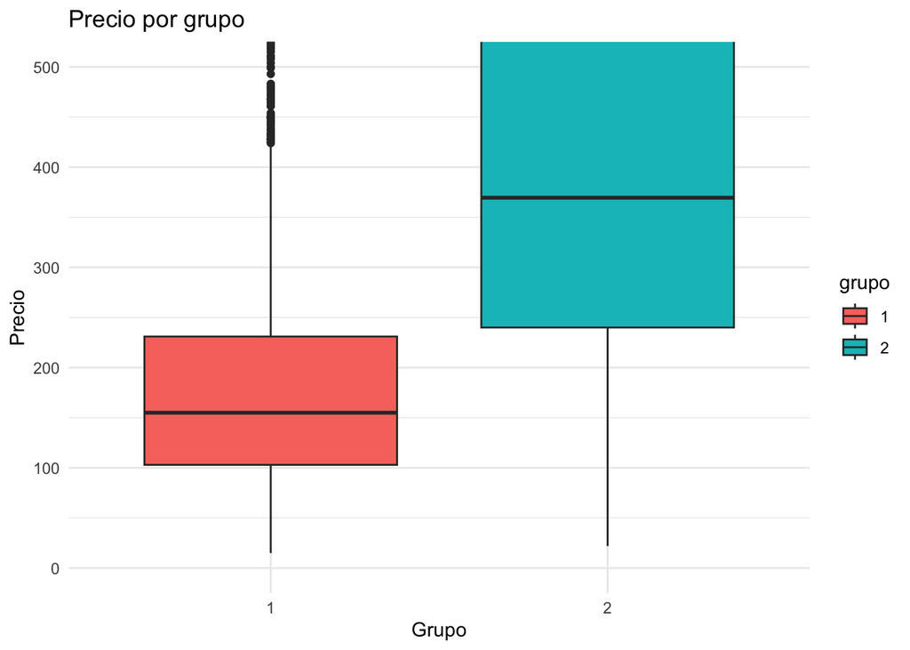

```r
ggplot(datos_muestra, aes(x = grupo, y = price, fill = grupo)) +
  geom_boxplot() +
  coord_cartesian(ylim = c(0, 500)) +
  labs(title = "Precio por grupo", x = "Grupo", y = "Precio") +
  theme_minimal()
```

```r
kruskal.test(price ~ grupo, data = datos_muestra)
```

```
##
##  Kruskal-Wallis rank sum test
##
## data:  price by grupo
## Kruskal-Wallis chi-squared = 768.23, df = 1, p-value < 2.2e-16
```

## 4. Divida el set de datos preprocesados

Dividalos en dos conjuntos: Entrenamiento y prueba. Describa el criterio que usó para crear los conjuntos: número de filas de cada uno, estratificado o no, balanceado o no, etc.

```r
set.seed(123)

pricing_without_na <- listings[!is.na(listings$price), ]

trainIndex <- createDataPartition(pricing_without_na$price, p = .7, list = FALSE)
train <- pricing_without_na[trainIndex, ]
test <- pricing_without_na[-trainIndex, ]
```

Tratamiento de outliers en ‘price’ (IQR) sin perder filas: En vez de eliminar registros (lo que puede dejar 0 casos para entrenar), recortamos (winsorizamos) el precio a los límites IQR calculados en TRAIN. [Esta seccion del codigo fue Generado por ChatGPT para ayudarnos a limpiar los outliers sin perder filas] [El resto del codigo es nuestro tomando en base el repositorio de erick]

```r
Q1 <- quantile(train$price, 0.25, na.rm = TRUE)
Q3 <- quantile(train$price, 0.75, na.rm = TRUE)
IQR_value <- Q3 - Q1

low  <- as.numeric(Q1 - 1.5 * IQR_value)
high <- as.numeric(Q3 + 1.5 * IQR_value)

cat("IQR bounds price (train):", low, "to", high, "\n")
```

```
## IQR bounds price (train): -189 to 635
```

```r
cat("Rows before -> train:", nrow(train), ", test:", nrow(test), "\n")
```

```
## Rows before -> train: 53373 , test: 22873
```

```r
# Clip/Winsorize
train$price <- pmin(pmax(train$price, low), high)
test$price  <- pmin(pmax(test$price,  low), high)

cat("Rows after  -> train:", nrow(train), ", test:", nrow(test), "\n")
```

```
## Rows after  -> train: 53373 , test: 22873
```

```r
cat("NA counts -> price/train:", sum(is.na(train$price)), ", bedrooms/train:", sum(is.na(train$bedrooms)), "\n")
```

```
## NA counts -> price/train: 0 , bedrooms/train: 81
```

Entrenamos con el 70% de los datos y probamos con el 30% restante. La partición se hizo de manera estratificada para mantener la distribución del precio en ambos conjuntos. Luego, se aplicó un recorte (winsorización) de outliers en `price` con límites IQR calculados en entrenamiento, para reducir el impacto de valores extremos sin eliminar observaciones.

## 5. Haga ingeniería de características

¿qué variables cree que puedan ser mejores predictores para el precio de las casas? Explique en que basó la selección o no de las variables.

### Prueba de Supuestos

Nuestros supuestos son los siguientes: 1. Los cuatros (bedrooms) son linealmente relacionados con el precio. 2. Los baños (bathrooms) son linealmente relacionados con el precio. 3. La calificación de las reseñas (review_scores_rating) es linealmente relacionada con el precio.

```r
train_bedrooms <- train[complete.cases(train[, c("price", "bedrooms")]), ]
train_bathrooms <- train[complete.cases(train[, c("price", "bathrooms")]), ]
train_reviews <- train[complete.cases(train[, c("price", "review_scores_rating")]), ]

model_bedrooms <- lm(price ~ bedrooms, data = train_bedrooms)
model_bathrooms <- lm(price ~ bathrooms, data = train_bathrooms)
model_ReviewScore <- lm(price ~ review_scores_rating, data = train_reviews)
```

### Linealidad

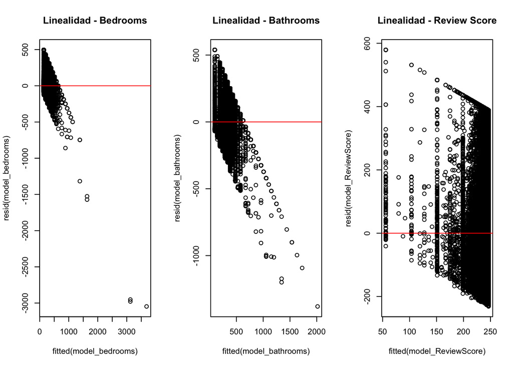

```r
par(mfrow = c(1, 3))
plot(
  fitted(model_bedrooms),
  resid(model_bedrooms),
  main = "Linealidad - Bedrooms"
)
abline(h = 0, col = "red")

plot(
  fitted(model_bathrooms),
  resid(model_bathrooms),
  main = "Linealidad - Bathrooms"
)
abline(h = 0, col = "red")

plot(
  fitted(model_ReviewScore),
  resid(model_ReviewScore),
  main = "Linealidad - Review Score"
)
abline(h = 0, col = "red")
```

```r
par(mfrow = c(1, 1))
```

### Normalidad de los residuos

Segun la prueba de Shapiro-Wilk, los residuos de los modelos no siguen una distribución normal, lo que podría afectar la validez de las inferencias basadas en estos modelos. Sin embargo, dado el tamaño de la muestra, es posible que esta falta de normalidad no tenga un impacto significativo en la capacidad predictiva del modelo. Muy seguramente, la falta de normalidad se deba a la presencia de valores atípicos o a una distribución sesgada de los residuos, lo que es común en datos de precios.

Regla de decisión: * Si p-value ≤ 0.05 → Se rechaza H₀ (evidencia de no normalidad).

```r
sample_resid_bedrooms <- sample(resid(model_bedrooms), 5000)
sample_resid_bathrooms <- sample(resid(model_bathrooms), 5000)
sample_resid_ReviewScore <- sample(resid(model_ReviewScore), 5000)

shapiro.test(sample_resid_bedrooms)
```

```
##
##  Shapiro-Wilk normality test
##
## data:  sample_resid_bedrooms
## W = 0.90705, p-value < 2.2e-16
```

```r
shapiro.test(sample_resid_bathrooms)
```

```
##
##  Shapiro-Wilk normality test
##
## data:  sample_resid_bathrooms
## W = 0.91878, p-value < 2.2e-16
```

```r
shapiro.test(sample_resid_ReviewScore)
```

```
##
##  Shapiro-Wilk normality test
##
## data:  sample_resid_ReviewScore
## W = 0.85344, p-value < 2.2e-16
```

### Homocedasticidad

Regla de decisión: * Si p-value > 0.05 → No se rechaza H₀ (varianza constante). * Si p-value ≤ 0.05 → Se rechaza H₀ (existe heterocedasticidad).

```r
bptest(model_bedrooms)
```

```
##
##  studentized Breusch-Pagan test
##
## data:  model_bedrooms
## BP = 5527.4, df = 1, p-value < 2.2e-16
```

```r
bptest(model_bathrooms)
```

```
##
##  studentized Breusch-Pagan test
##
## data:  model_bathrooms
## BP = 3308.4, df = 1, p-value < 2.2e-16
```

```r
bptest(model_ReviewScore)
```

```
##
##  studentized Breusch-Pagan test
##
## data:  model_ReviewScore
## BP = 39.836, df = 1, p-value = 2.762e-10
```

Hipótesis:

- H₀: La varianza de los errores es constante (homocedasticidad).
- H₁: La varianza de los errores no es constante (heterocedasticidad).

### Independencia

En el caso de todos los modelos, el valor de Durbin-Watson tiene un p value menor a 0.05, lo que indica que hay evidencia de autocorrelación de primer orden en los residuos. Esto sugiere que los errores no son independientes, lo que podría afectar la validez de las inferencias basadas en estos modelos. * Si p-value ≤ 0.05 → Se rechaza H₀ (evidencia de autocorrelación).

```r
dwtest(model_bedrooms)
```

```
##
##  Durbin-Watson test
##
## data:  model_bedrooms
## DW = 1.4031, p-value < 2.2e-16
## alternative hypothesis: true autocorrelation is greater than 0
```

```r
dwtest(model_bathrooms)
```

```
##
##  Durbin-Watson test
##
## data:  model_bathrooms
## DW = 1.4533, p-value < 2.2e-16
## alternative hypothesis: true autocorrelation is greater than 0
```

```r
dwtest(model_ReviewScore)
```

```
##
##  Durbin-Watson test
##
## data:  model_ReviewScore
## DW = 1.6713, p-value < 2.2e-16
## alternative hypothesis: true autocorrelation is greater than 0
```

Hipótesis:

- H₀: No existe autocorrelación de primer orden en los residuos.
- H₁: Existe autocorrelación de primer orden en los residuos.

## 6. Todos los resultados deben ser reproducibles por lo que debe fijar que los conjuntos de entrenamiento y

prueba sean los mismos siempre que se ejecute el código.

## 7. Modelo univariado de regresión lineal

Seleccione una de las variables y haga un modelo univariado de regresión lineal para predecir el precio de las casas. Analice el modelo (resumen, residuos, resultados de la predicción). Muéstrelo gráficamente.

```r
model_single <- lm(price ~ bedrooms, data=train)
summary(model_single)
```

```
##
## Call:
## lm(formula = price ~ bedrooms, data = train)
##
## Residuals:
##      Min       1Q   Median       3Q      Max
## -3047.04  -106.12   -37.28    63.88   496.04
##
## Coefficients:
##             Estimate Std. Error t value Pr(>|t|)
## (Intercept)  138.958      1.096   126.8   <2e-16 ***
## bedrooms      62.159      0.480   129.5   <2e-16 ***
## ---
## Signif. codes:  0 '***' 0.001 '**' 0.01 '*' 0.05 '.' 0.1 ' ' 1
##
## Residual standard error: 154 on 53290 degrees of freedom
##   (81 observations deleted due to missingness)
## Multiple R-squared:  0.2393, Adjusted R-squared:  0.2393
## F-statistic: 1.677e+04 on 1 and 53290 DF,  p-value: < 2.2e-16
```

```r
pred_full_single <- predict(model_single, newdata = test[, cuantitativas])
actual_full_single <- test$price
```

## 8. Modelo de regresión lineal

Haga un modelo de regresión lineal con todas las variables numéricas para predecir el precio de las casas. Analice el modelo (resumen, residuos, resultados de la predicción). Muestre el modelo gráficamente.

```r
model_full <- lm(price ~ ., data = train[, cuantitativas])
summary(model_full)
```

```
##
## Call:
## lm(formula = price ~ ., data = train[, cuantitativas])
##
## Residuals:
##      Min       1Q   Median       3Q      Max
## -1885.95   -69.69   -18.96    46.39   715.43
##
## Coefficients:
##                                                Estimate Std. Error t value
## (Intercept)                                  -6.315e+02  1.971e+01 -32.037
## host_listings_count                          -1.445e-02  3.749e-03  -3.855
## host_total_listings_count                     1.192e-02  2.298e-03   5.187
## accommodates                                  1.688e+01  4.262e-01  39.610
## bedrooms                                      1.182e+01  8.584e-01  13.773
## beds                                          1.551e+00  5.616e-01   2.762
## minimum_nights                                7.347e-01  1.030e-01   7.130
## minimum_nights_avg_ntm                       -1.334e+00  1.600e-01  -8.335
## maximum_nights                                4.092e-03  1.456e-03   2.811
## maximum_nights_avg_ntm                       -7.803e-08  4.244e-08  -1.838
## minimum_minimum_nights                       -3.688e-01  1.379e-01  -2.675
## maximum_minimum_nights                        2.957e-01  4.531e-02   6.525
## availability_30                               9.646e-01  1.463e-01   6.595
## availability_60                              -3.801e-01  1.535e-01  -2.476
## availability_90                               1.717e+00  1.768e-01   9.711
## availability_365                              2.087e-02  6.827e-03   3.058
## number_of_reviews                             9.074e-03  8.231e-03   1.102
## number_of_reviews_ltm                         8.189e-01  9.546e-02   8.579
## number_of_reviews_l30d                        1.148e-01  5.165e-01   0.222
## availability_eoy                             -1.945e+00  1.275e-01 -15.255
## number_of_reviews_ly                          2.258e-01  6.261e-02   3.606
## estimated_occupancy_l365d                    -3.071e-01  1.197e-02 -25.662
## reviews_per_month                            -1.155e+01  7.195e-01 -16.060
## minimum_maximum_nights                       -1.477e-02  1.336e-03 -11.057
## maximum_maximum_nights                        9.555e-08  4.072e-08   2.347
## host_response_rate                           -3.284e-01  6.527e-02  -5.031
## host_acceptance_rate                          6.524e-02  3.888e-02   1.678
## latitude                                      5.811e+00  2.384e-01  24.376
## longitude                                    -1.804e+00  5.820e-02 -30.992
## bathrooms                                     3.838e+01  9.721e-01  39.484
```

[output cut: 47 more lines]

```
## review_scores_communication                  8.58e-09 ***
## review_scores_location                        < 2e-16 ***
## review_scores_value                           < 2e-16 ***
## calculated_host_listings_count                < 2e-16 ***
## calculated_host_listings_count_entire_homes   < 2e-16 ***
## calculated_host_listings_count_private_rooms  < 2e-16 ***
## calculated_host_listings_count_shared_rooms   < 2e-16 ***
## estimated_revenue_l365d                       < 2e-16 ***
## ---
## Signif. codes:  0 '***' 0.001 '**' 0.01 '*' 0.05 '.' 0.1 ' ' 1
##
## Residual standard error: 113.4 on 41209 degrees of freedom
##   (12122 observations deleted due to missingness)
## Multiple R-squared:  0.5334, Adjusted R-squared:  0.5329
## F-statistic:  1149 on 41 and 41209 DF,  p-value: < 2.2e-16
```

```r
pred_full <- predict(model_full, newdata = test[, cuantitativas])
actual_full <- test$price
```

## 9. Analice el modelo.

Determine si hay multicolinealidad entre las variables, y cuáles son las que aportan al modelo. Haga un análisis de correlación de las características del modelo y especifique si el modelo se adapta bien a los datos. Explique si hay sobreajuste (overfitting) o no. En caso de existir sobreajuste, haga otro modelo que lo corrija.

```r
vif(model_full)
```

```
##                          host_listings_count
##                                     7.567422
##                    host_total_listings_count
##                                     6.206849
##                                 accommodates
##                                     5.105713
##                                     bedrooms
##                                     4.254190
##                                         beds
##                                     4.146203
##                               minimum_nights
##                                     6.725774
##                       minimum_nights_avg_ntm
##                                    14.839169
##                               maximum_nights
##                                     1.245863
##                       maximum_nights_avg_ntm
##                                    29.127493
##                       minimum_minimum_nights
##                                     9.840513
##                       maximum_minimum_nights
##                                     3.279487
##                              availability_30
##                                     6.141708
##                              availability_60
##                                    24.509974
##                              availability_90
##                                    68.335866
##                             availability_365
##                                     1.640504
##                            number_of_reviews
##                                     2.378866
##                        number_of_reviews_ltm
##                                     9.959884
##                       number_of_reviews_l30d
##                                     2.520490
##                             availability_eoy
##                                    44.303323
##                         number_of_reviews_ly
##                                     4.679056
```

[output cut: 27 more lines]

```
##                                     2.699035
##                       review_scores_location
##                                     1.680051
##                          review_scores_value
##                                     3.608324
##               calculated_host_listings_count
##                                   975.484115
##  calculated_host_listings_count_entire_homes
##                                   965.480563
## calculated_host_listings_count_private_rooms
##                                     5.475189
##  calculated_host_listings_count_shared_rooms
##                                     1.610718
##                      estimated_revenue_l365d
##                                     1.103537
```

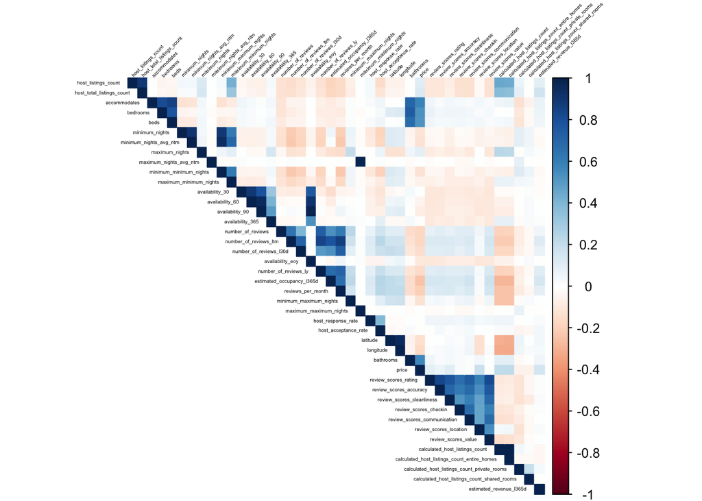

```r
cor_matrix_model <- cor(train[, cuantitativas], use = "complete.obs")


corrplot(cor_matrix_model,
         method = "color",
         type = "upper",
         tl.col = "black",
         tl.srt = 45,
         tl.cex = 0.3,
         addCoef.col = NULL)
```

El análisis de multicolinealidad mostró que varias variables presentan valores altos de VIF, especialmente las relacionadas con la disponibilidad (availability_90, availability_eoy) y los conteos de propiedades del host (calculated_host_listings_count), indicando fuerte colinealidad entre ellas. Esto afecta la estabilidad e interpretación del modelo completo. El corrplot confirma estas relaciones altas entre variables similares. Aunque no se observa un sobreajuste severo al comparar con el modelo Lasso, es recomendable simplificar el modelo eliminando variables redundantes para mejorar su robustez y facilitar su interpretación.

## 10. Si tiene multicolinealidad o sobreajuste, haga un modelo con las variables que sean mejores predictoras del precio de las casas. Determine la calidad del modelo realizando un análisis de los residuos. Muéstrelo gráficamente.

```r
model_reduced <- lm(price ~ accommodates + bedrooms + beds + bathrooms,
                    data = train)

summary(model_reduced)
```

```
##
## Call:
## lm(formula = price ~ accommodates + bedrooms + beds + bathrooms,
##     data = train)
##
## Residuals:
##     Min      1Q  Median      3Q     Max
## -688.91  -88.16  -36.26   57.98  529.13
##
## Coefficients:
##              Estimate Std. Error t value Pr(>|t|)
## (Intercept)   62.7396     1.2570  49.912  < 2e-16 ***
## accommodates  26.8367     0.4104  65.395  < 2e-16 ***
## bedrooms      -4.4149     0.8488  -5.201 1.99e-07 ***
## beds          -6.1232     0.5698 -10.747  < 2e-16 ***
## bathrooms     51.2880     0.9962  51.485  < 2e-16 ***
## ---
## Signif. codes:  0 '***' 0.001 '**' 0.01 '*' 0.05 '.' 0.1 ' ' 1
##
## Residual standard error: 140.8 on 53229 degrees of freedom
##   (139 observations deleted due to missingness)
## Multiple R-squared:  0.3636, Adjusted R-squared:  0.3636
## F-statistic:  7603 on 4 and 53229 DF,  p-value: < 2.2e-16
```

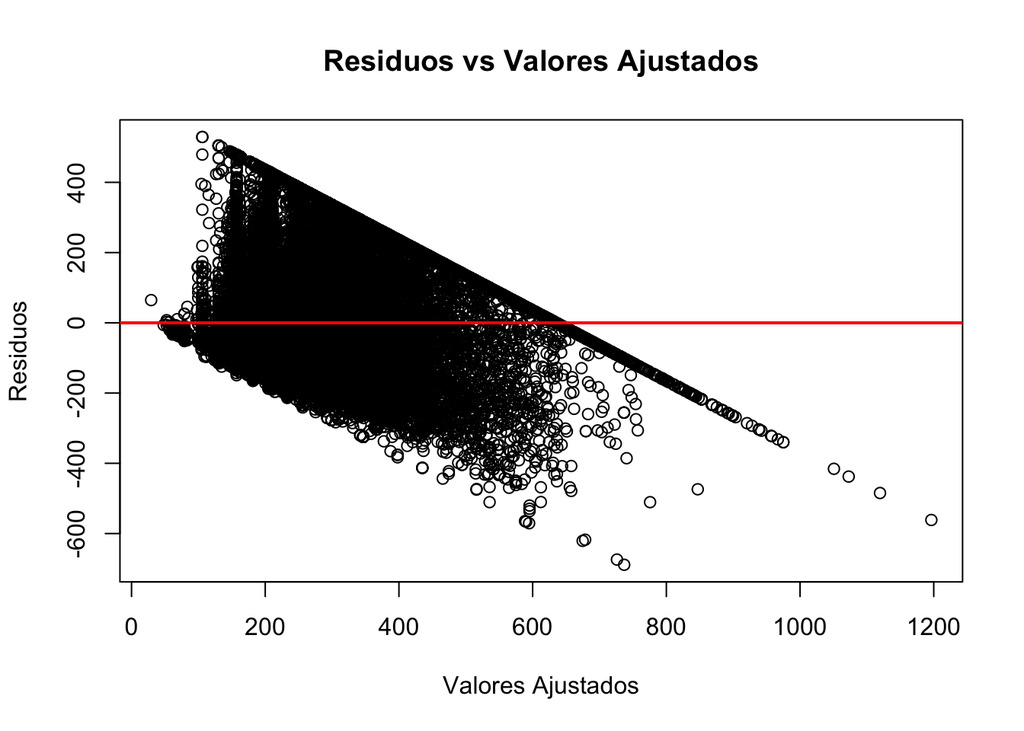

```r
plot(model_reduced$fitted.values,
     resid(model_reduced),
     main = "Residuos vs Valores Ajustados",
     xlab = "Valores Ajustados",
     ylab = "Residuos")

abline(h = 0, col = "red", lwd = 2)
```

## 11. Elabore un modelo en el que utilice al menos una de las técnicas de regularización

(Ridge, Lasso, ElasticNet) compare los resultados con los otros modelos.

```r
train_clean <- na.omit(train[, cuantitativas])
test_clean <- na.omit(test[, cuantitativas])

x_train <- as.matrix(train_clean[, setdiff(cuantitativas, "price")])
y_train <- train_clean$price

x_test <- as.matrix(test_clean[, setdiff(cuantitativas, "price")])
y_test <- test_clean$price

set.seed(123)
cv_lasso <- cv.glmnet(x_train, y_train, alpha = 1)
best_lambda <- cv_lasso$lambda.min

model_lasso <- glmnet(x_train, y_train, alpha = 1, lambda = best_lambda)

pred_lasso <- predict(model_lasso, s = best_lambda, newx = x_test)
pred_lasso <- as.numeric(pred_lasso)

actual_lasso <- y_test

r2_test <- function(actual, predicted) {
  ss_res <- sum((actual - predicted)^2, na.rm = TRUE)
  ss_tot <- sum((actual - mean(actual, na.rm = TRUE))^2, na.rm = TRUE)
  1 - ss_res / ss_tot
}

results_lasso <- data.frame(
  Modelo = c("Regresión Lasso (Regularización)"),
  RMSE = c(
    caret::RMSE(pred_lasso, actual_lasso)
  ),
  R2 = c(
    r2_test(actual_lasso, pred_lasso)
  )
)

results_lasso
```

```
##                             Modelo     RMSE        R2
## 1 Regresión Lasso (Regularización) 111.9871 0.5300248
```

¿Por que escogimos lasso?

En bases de datos de viviendas suele haber muchas variables numéricas que miden cosas similares. Lasso aplica un tipo de castigo matemático llamado “penalización L1”. Lo especial de esta penalización es que, si una variable no aporta valor real para predecir el precio, Lasso reduce su coeficiente exactamente a cero, eliminándola del modelo por completo.

## 12. Utilice cada modelo con el conjunto de prueba

Determine la eficiencia del algoritmo para predecir el precio de las casas. ¿Qué tan bien lo hizo? ¿Qué medidas usó para determinar la calidad de la predicción?

```r
r2_test <- function(actual, predicted) {
  ss_res <- sum((actual - predicted)^2, na.rm = TRUE)
  ss_tot <- sum((actual - mean(actual, na.rm = TRUE))^2, na.rm = TRUE)
  1 - ss_res / ss_tot
}

# Remove NA values for fair comparison
valid_idx <- complete.cases(pred_full, actual_full)
pred_full_valid <- pred_full[valid_idx]
actual_full_valid <- actual_full[valid_idx]

results_full <- data.frame(
  Modelo = c("Regresión Lineal Completa"),
  RMSE = c(
    caret::RMSE(pred_full_valid, actual_full_valid)
  ),
  R2 = c(
    r2_test(actual_full_valid, pred_full_valid)
  )
)

results_full
```

```
##                      Modelo     RMSE        R2
## 1 Regresión Lineal Completa 112.0029 0.5298918
```

```r
valid_idx_single <- complete.cases(pred_full_single, actual_full_single)
pred_single_valid <- pred_full_single[valid_idx_single]
actual_single_valid <- actual_full_single[valid_idx_single]

results_single <- data.frame(
  Modelo = c("Regresión Lineal Univariada"),
  RMSE = c(
    caret::RMSE(pred_single_valid, actual_single_valid)
  ),
  R2 = c(
    r2_test(actual_single_valid, pred_single_valid)
  )
)

results_single
```

```
##                        Modelo    RMSE        R2
## 1 Regresión Lineal Univariada 150.646 0.2576685
```

```r
tabla_comparativa <- rbind(results_single, results_full, results_lasso)
tabla_comparativa
```

```
##                             Modelo     RMSE        R2
## 1      Regresión Lineal Univariada 150.6460 0.2576685
## 2        Regresión Lineal Completa 112.0029 0.5298918
## 3 Regresión Lasso (Regularización) 111.9871 0.5300248
```

Cada uno de los modelos tuvo un RMSE de alrededor de 110 a 150 y un R2 de alrededor de 0.26 a 0.53, lo que indica que los modelos explican entre el 25% y el 53% de la variabilidad en los precios de las casas. El modelo de regresión lineal completa tiene un mejor desempeño que el univariado, pero el modelo Lasso no muestra una mejora significativa en comparación con la regresión lineal completa, lo que sugiere que la regularización no aportó beneficios adicionales en este caso.

Por otro lado al haber obtenido un valor RMSE de alrededor de 110 a 150, esto indica que en promedio, las predicciones del modelo se desvían del precio real en esa cantidad, lo que sugiere que el modelo tiene un error considerable pero muy aceptable en sus predicciones.

## 13. Discuta sobre la efectividad de los modelos.

¿Cuál lo hizo mejor? ¿Cuál es el mejor modelo para predecir el precio de las casas? Haga los gráficos que crea que le pueden ayudar en la discusión.

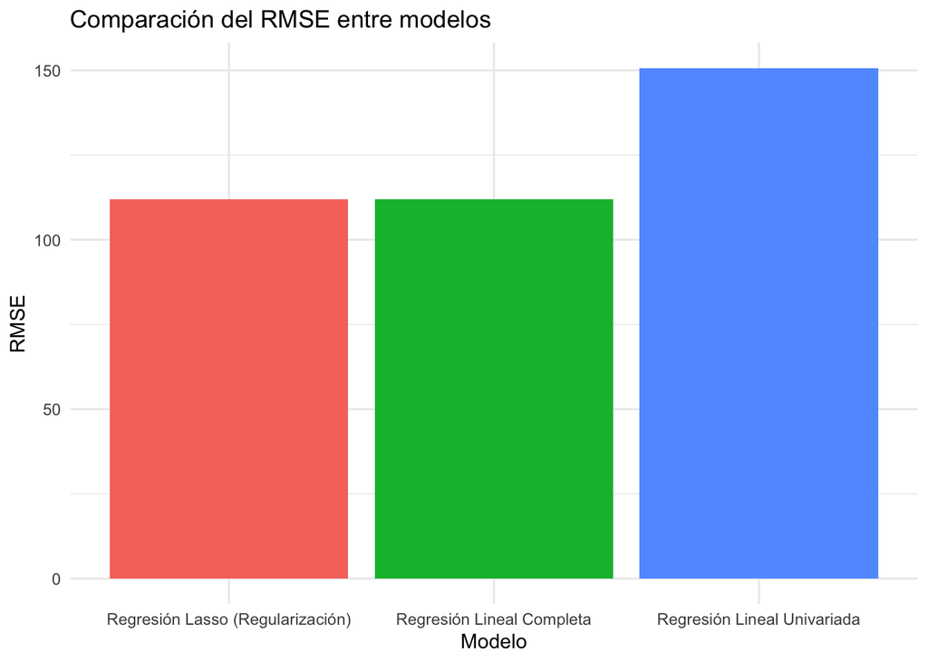

```r
ggplot(tabla_comparativa, aes(x = Modelo, y = RMSE, fill = Modelo)) +
  geom_bar(stat = "identity") +
  theme_minimal() +
  labs(title = "Comparación del RMSE entre modelos",
       x = "Modelo",
       y = "RMSE") +
  theme(legend.position = "none")
```

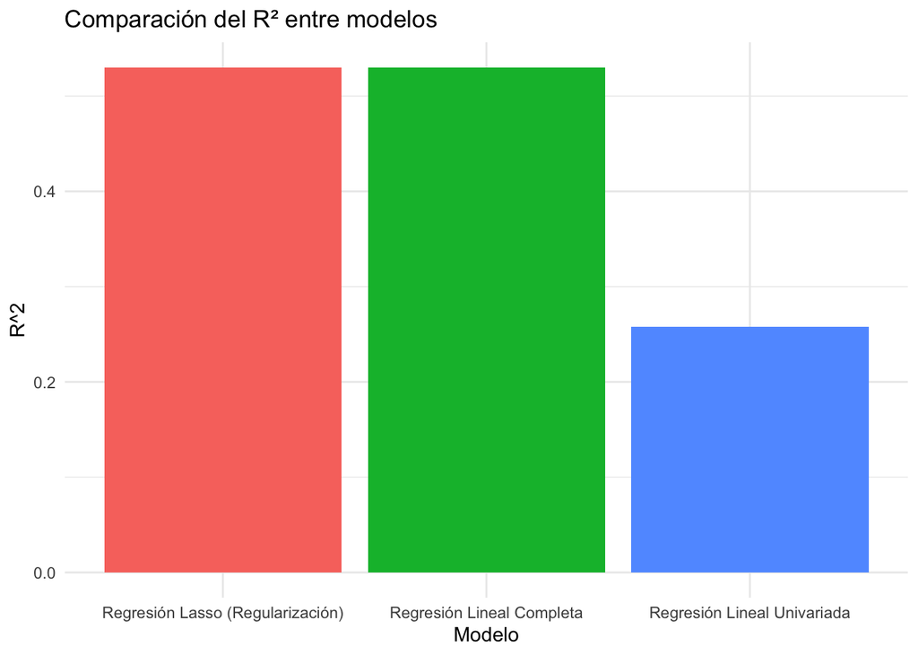

```r
ggplot(tabla_comparativa, aes(x = Modelo, y = R2, fill = Modelo)) +
  geom_bar(stat = "identity") +
  theme_minimal() +
  labs(title = "Comparación del R² entre modelos",
       x = "Modelo",
       y = "R^2") +
  theme(legend.position = "none")
```

El modelo con peor desempeño es la regresión lineal univariada, ya que presenta el RMSE más alto (150.646) y el R² más bajo (0.2577). Esto indica que solo explica aproximadamente el 25.7% de la variabilidad en los precios de las casas, por lo que su capacidad predictiva es limitada. Esto se debe a que utiliza una sola variable para hacer las predicciones, lo que no logra capturar todos los factores que influyen en el precio de las viviendas.

En cambio, la regresión lineal completa y la regresión Lasso muestran un desempeño mucho mejor, con un RMSE cercano a 112 y un R^2 alrededor de 0.53, lo que significa que explican cerca del 53% de la variabilidad del precio. El modelo Lasso tiene el RMSE ligeramente más bajo (111.9871) y el R^2 ligeramente más alto (0.5300), por lo que puede considerarse el mejor modelo, aunque la diferencia con la regresión lineal completa es mínima.

# Lab 4 - Decision Tree

## 1. Use los mismos conjuntos de entrenamiento

Prueba que usó para los modelos de regresión lineal en la entrega anterior.

## 2. árbol de regresión

Elabore un árbol de regresión para predecir el precio de las casas por noche usando todas las variables.

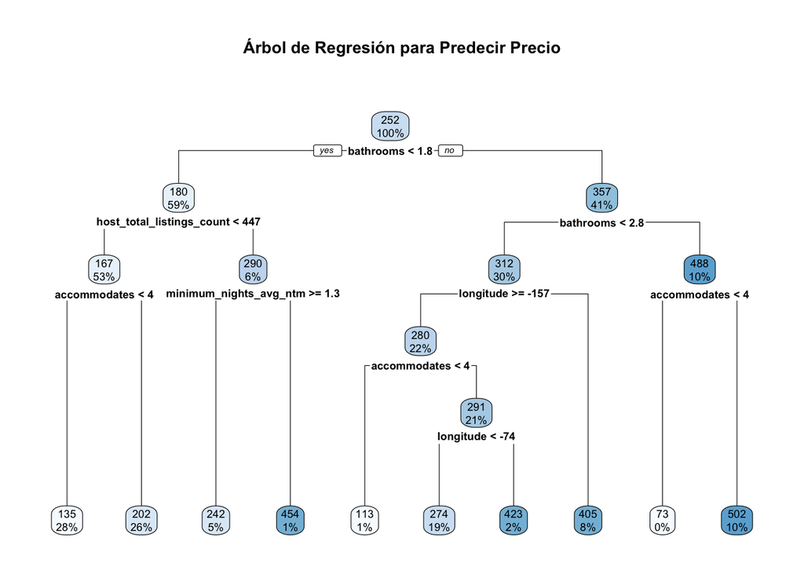

```r
set.seed(123)
formula_tree <- as.formula(paste("price ~", paste(setdiff(cuantitativas, "price"), collapse = " + ")))
tree_model <- rpart(formula_tree, data = train)
rpart.plot(tree_model, main = "Árbol de Regresión para Predecir Precio")
```

## 3. Resultado arbol de regresión

Úselo para predecir y analice el resultado. ¿Qué tal lo hizo?

```r
pred_tree <- predict(tree_model, newdata = test)
actual_tree <- test$price
results_tree <- data.frame(
  Modelo = c("Árbol de Regresión"),
  RMSE = c(
    caret::RMSE(pred_tree, actual_tree)
  ),
  R2 = c(
    r2_test(actual_tree, pred_tree)
  )
)
results_tree
```

```
##               Modelo    RMSE        R2
## 1 Árbol de Regresión 129.371 0.4530766
```

## 4. 3 modelos más cambiando la profundidad del árbol

Haga, al menos, 3 modelos más, cambiando el parámetro de la profundidad del árbol. ¿Cuál es el mejor modelo para predecir el precio por noche?

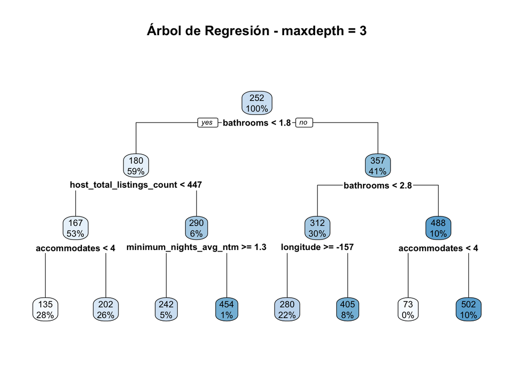

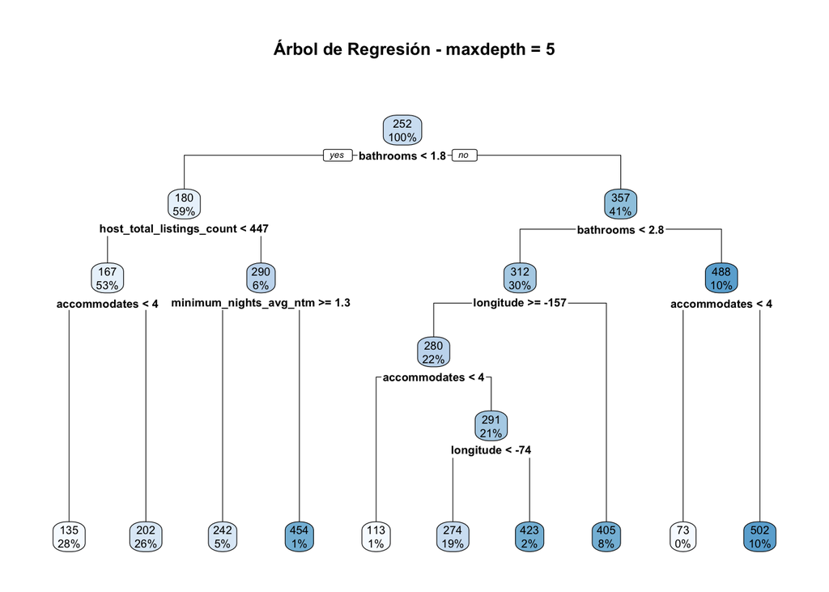

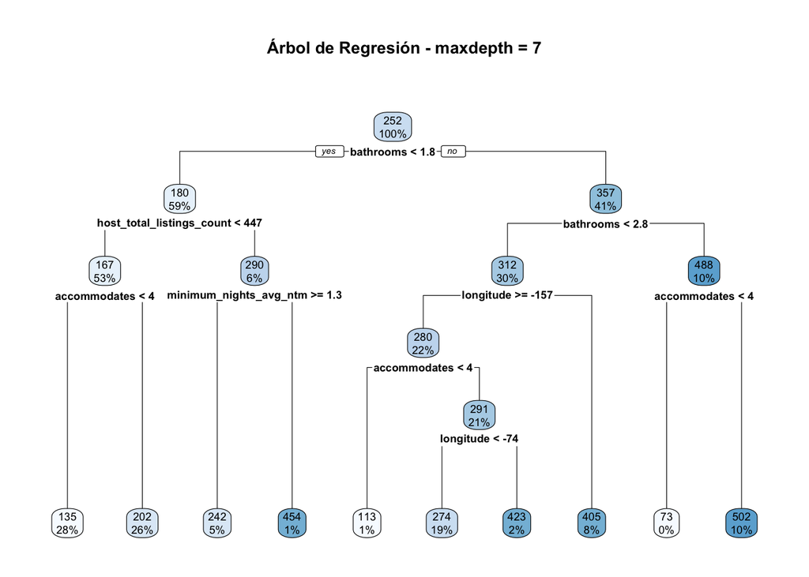

```r
set.seed(123)
depths <- c(3, 5, 7)
results_depth <- data.frame()
for (d in depths) {
  tree_model_d <- rpart(formula_tree, data = train, control = rpart.control(maxdepth = d))
  rpart.plot(tree_model_d, main = paste("Árbol de Regresión - maxdepth =", d))
  pred_d <- predict(tree_model_d, newdata = test)
  results_depth <- rbind(results_depth, data.frame(
    Modelo = paste("Árbol maxdepth =", d),
    RMSE = caret::RMSE(pred_d, actual_tree),
    R2 = r2_test(actual_tree, pred_d)
  ))
}
```

## 5. Comparación de modelos Compare los resultados con el modelo de regresión lineal de la hoja anterior, ¿cuál lo hizo mejor?

```r
results_depth
```

```
##               Modelo     RMSE        R2
## 1 Árbol maxdepth = 3 132.9424 0.4224632
## 2 Árbol maxdepth = 5 129.3710 0.4530766
## 3 Árbol maxdepth = 7 129.3710 0.4530766
```